# NDVI data description

M. Rolland

21/07/2020

# 1 Litterature

(Agay-Shay et al. 2019):

- continuous NDVI
- smoothed with LOWESS
- 300m buffer
- maternal address at birth date
- also trimester specific and entire pregnancy length mean
- - pregnancy NDVI standard deviantion

(Akaraci et al. 2020): (meta analysis shows non signif assoc w/ ptb)

(Asta et al. 2019):

- distance from a major green area: classified women as living within 100 m, between 100 m and 500 m, and beyond 500 m from green spaces
- summer values (17-07-2015)
- We selected a summer day, chosen as it had the least amount of cloud cover at the time of year when leaf development would be at a maximum
- Finally, we calculated the average of NDVI in each 100 m buffer around of the mothers’ residential addresses and classified each woman using NDVI’s tertiles

(Kathryn Abelt and Sara McLafferty 2017):

- mixed-effects linear and logistic regression models
- 6 July 1999: We selected this image because it contained minimal (<10%) cloud contamination, encompassed the whole of the study area, and was captured during the Summer (…), which is generally the ‘greenest’ portion of the year in the northern hemisphere
- Mean NDVI values were calculated for 100 m, 250 m, and 500 m circular buffers around the population-weighted centroid of each mother’s census tract of residence

(Dzhambov, Markevych, and Lercher 2019):

- Only mothers who had lived in their current residence during the whole pregnancy were included.
- Normalized Difference Vegetation Index (NDVI) in the year of birth
- summertime images because summer is the time when variance in NDVI is the highest
- NDVI was calculated as mean values in circular buffers of 100 m, 300 m, 500 m, and 1000m around the residential address
- **In linewith a previous study in Bavaria (Markevych et al., 2014) which found most consistent associations for the 500-mbuffer,we consideredNDVI500-m for themain analyses; however, we also report sensitivity analyses with the other buffers.**

(Glazer et al. 2018):

- Residential home address at the time of delivery
- 150, 250 and 500 m buffer
- main analyses: 500m buffer (high correlation with others)

(Sun et al. 2020):

- Negative (NDVI) values, representing water bodies, were removed
- 250 m, 500 m, 1000 m, and 2000 m
- mean month and pregnancy values
- time-to-event regression models, and term births were censored at week 37. Specifically, Cox proportional hazard models were applied to estimate the hazard ratios (HRs) and 95% confidence intervals (CIs) for per interquartile range (IQR) increase in NDVI during the entire pregnancy in California
- ZIP codes were fitted as a random effect in the models to account for potential spatial clustering for PTB
- sensitivity analyses to examine the influence of adjusting for season of conception (warm: May-October; cool: November–April), year of birth (2001–2008), maternal smoking status during pregnancy, and maternal comorbidities (chronic hypertension, diabetes, preeclampsia, and gestational diabetes)
- **Cochran Q tests were used to measure the heterogeneity among subgroups.**

Other:

- several studies show interaction with SES (stratify on SES?)

Final choice:

- 500m buffer
- summer values
- mother’s adress at birth
- year closest to birth

# 2 Données - Variables

Cf doc `Documentation_calcul_expo_EDEN_PELAGIE_04062020.docx`

- France métropolitaine uniquement
- Moyenne NDVI été et hiver et pourcentage de pixels = 0 pour 3 buffers autour de l’adresse : 100m, 300m et 500m
- Pour l’année de naissance du sujet et chaque année calendaire de son suivi, indépendamment d’un déménagement dans l’année
- Format long avec une ligne par sujet, par adresse et par année
- `buffer_ndvi_saison`: ndvi moyen à la saison (été ou hiver) pour un buffer donné (100m, 300M, 500m)
- `buffer_pct0_saison`: Le pourcentage de pixels = 0 à la saison pour un buffer donné, permet d’invalider les valeurs de NDVI. En effet on peut fixer un seuil, par exemple 25%, à partir duquel on décide que les moyennes ont été calculées avec trop peu de pixels (car nuages par exemple) et donc mettre à NA ces valeurs.

# 3 Description

Pelagie data selected:

- Q6 data
- Q2 when id not in Q6
- GRO when id in neither Q6 or Q2

**Final data = first adress of year of birth *(see to discuss section)***

N individuals with NDVI data:

N by cohort

| cohort | Freq |
| --- | --- |
| Eden | 1889 |
| Pelagie | 3313 |
| Sepages | 478 |

N data with 500m data with pct0 > 25%:

data with less than 75% pixels

| cohort | Freq |
| --- | --- |
| Pelagie | 99 |

NDVI distribution

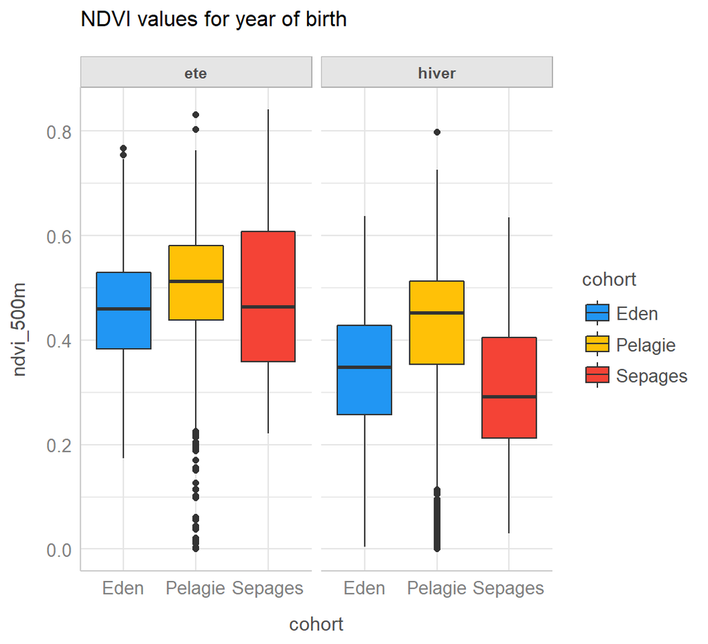

Correlations between different buffers:

Buffer correlation

| cohort | 100_300 | 100_500 | 300_500 |
| --- | --- | --- | --- |
| Eden | 0.83 | 0.76 | 0.96 |
| Pelagie | 0.86 | 0.77 | 0.95 |
| Sepages | 0.93 | 0.90 | 0.98 |

Correlations between winter/summer:

Season correlation

| cohort | sum_win_100 | sum_win_300 | sum_win_500 |
| --- | --- | --- | --- |
| Eden | 0.60 | 0.57 | 0.57 |
| Pelagie | 0.52 | 0.46 | 0.44 |
| Sepages | 0.84 | 0.85 | 0.86 |

# 4 To discuss

- For eden - pelagie data I don’t have start date and end date of each adress so when 2 adresses in a given year i don’t know which ones correspond to the adress at birth. Because Ariane has left them on the sepages NDVI, she thinks it is probably very straight forward to add them to eden_pelagie. **for now I arbitrarily use use the first date at that year**
- Not possible to have pregnancy mean NDVI? (mean of continuous NDVI across pregnancy) => according to ian complicated to compute, so i suggest we keep the summer value 500m buffer and go more in detrail if reviewers ask so, and we can explore in the sensitivity analysis

# References

Agay-Shay, Keren, Yaron Michael, Xavier Basagaña, Èrica Martínez-Solanas, David Broday, Itamar M Lensky, Mary Rudolf, et al. 2019. “Mean and Variance of Greenness and Pregnancy Outcomes in Tel Aviv During 2000–14: Longitudinal and Cross-Sectional Approaches.” *International Journal of Epidemiology* 48 (4): 1054–72. https://doi.org/10.1093/ije/dyy249.

Akaraci, Selin, Xiaoqi Feng, Thomas Suesse, Bin Jalaludin, and Thomas Astell-Burt. 2020. “A Systematic Review and Meta-Analysis of Associations Between Green and Blue Spaces and Birth Outcomes.” *International Journal of Environmental Research and Public Health* 17 (8): 2949. https://doi.org/10.3390/ijerph17082949.

Asta, Michelozzi, Cesaroni, Sario, Badaloni, Davoli, and Schifano. 2019. “The Modifying Role of Socioeconomic Position and Greenness on the Short-Term Effect of Heat and Air Pollution on Preterm Births in Rome, 2001–2013.” *International Journal of Environmental Research and Public Health* 16 (14): 2497. https://doi.org/10.3390/ijerph16142497.

Dzhambov, Angel M., Iana Markevych, and Peter Lercher. 2019. “Associations of Residential Greenness, Traffic Noise, and Air Pollution with Birth Outcomes Across Alpine Areas.” *Science of the Total Environment* 678 (August): 399–408. https://doi.org/10.1016/j.scitotenv.2019.05.019.

Glazer, Kimberly B., Melissa N. Eliot, Valery A. Danilack, Lynn Carlson, Maureen G. Phipps, Payam Dadvand, David A. Savitz, and Gregory A. Wellenius. 2018. “Residential Green Space and Birth Outcomes in a Coastal Setting.” *Environmental Research* 163 (May): 97–107. https://doi.org/10.1016/j.envres.2018.01.006.

Kathryn Abelt, and Sara McLafferty. 2017. “Green Streets: Urban Green and Birth Outcomes.” *International Journal of Environmental Research and Public Health* 14 (7): 771. https://doi.org/10.3390/ijerph14070771.

Sun, Yi, Paige Sheridan, Olivier Laurent, Jia Li, David A. Sacks, Heidi Fischer, Yang Qiu, et al. 2020. “Associations Between Green Space and Preterm Birth: Windows of Susceptibility and Interaction with Air Pollution.” *Environment International* 142 (September): 105804. https://doi.org/10.1016/j.envint.2020.105804.